# Introduction to Machine Learning, Exercise solutions

Antti Salopuro

November 6, 2018

# Week 1, exercises

## Task 1

Task 1 b) (pen and paper)

*(b) (2 points) The Hoeffding bounds are typically quite conservative: the obtained confidence intervals are actually so wide that they contain the true value with too high confidence (higher than 1−α probability). To see that this is indeed the case, simulate the 10000 repetitions of the experiment by drawing binomial outcomes (which correspond to the number of 1’s in n i.i.d. Bernoulli r.v.s) using rbinom(10000, n, p) with parameter values p = 0.5, 0.9, 0.99, and checking how many times the outcome is within the interval you calculated in the previous item. The theory says that with α = 0.05, for example, the outcome should be inside the interval at least 95% of the time. Repeat again with n = 10, 100, 1000.*

```r
print("Parameter values: n = 10, p = 0.5")
```

```
## [1] "Parameter values: n = 10, p = 0.5"
```

```r
n <- 10
p <- 0.5
eps <- sqrt(log(40)/(2*n))
a <- rbinom(10000,n,p)
#(a < (n*(p+eps)))& (a > (n*(p-eps)))
s <- sum((a < (n*(p+eps)))& (a > (n*(p-eps))))/10000
message("Pct of cases that fit in the interval: ", s*100)
```

```
## Pct of cases that fit in the interval: 99.82
```

```r
print("Parameter values: n = 10, p = 0.9")
```

```
## [1] "Parameter values: n = 10, p = 0.9"
```

```r
n <- 10
p <- 0.9
eps <- sqrt(log(40)/(2*n))
a <- rbinom(10000,n,p)
#(a < (n*(p+eps)))& (a > (n*(p-eps)))
s <- sum((a < (n*(p+eps)))& (a > (n*(p-eps))))/10000
message("Pct of cases that fit in the interval: ", s*100)
```

```
## Pct of cases that fit in the interval: 99.99
```

```r
print("Parameter values: n = 10, p = 0.99")
```

```
## [1] "Parameter values: n = 10, p = 0.99"
```

```r
n <- 10
p <- 0.99
eps <- sqrt(log(40)/(2*n))
a <- rbinom(10000,n,p)
#(a < (n*(p+eps)))& (a > (n*(p-eps)))
s <- sum((a < (n*(p+eps)))& (a > (n*(p-eps))))/10000
message("Pct of cases that fit in the interval: ", s*100)
```

```
## Pct of cases that fit in the interval: 100
```

```r
print("Parameter values: n = 100, p = 0.5")
```

```
## [1] "Parameter values: n = 100, p = 0.5"
```

```r
n <- 100
p <- 0.5
eps <- sqrt(log(40)/(2*n))
a <- rbinom(10000,n,p)
#(a < (n*(p+eps)))& (a > (n*(p-eps)))
s <- sum((a < (n*(p+eps)))& (a > (n*(p-eps))))/10000
message("Pct of cases that fit in the interval: ", s*100)
```

```
## Pct of cases that fit in the interval: 99.35
```

```r
print("Parameter values: n = 100, p = 0.9")
```

```
## [1] "Parameter values: n = 100, p = 0.9"
```

```r
n <- 100
p <- 0.9
eps <- sqrt(log(40)/(2*n))
a <- rbinom(10000,n,p)
#(a < (n*(p+eps)))& (a > (n*(p-eps)))
s <- sum((a < (n*(p+eps)))& (a > (n*(p-eps))))/10000
message("Pct of cases that fit in the interval: ", s*100)
```

```
## Pct of cases that fit in the interval: 99.98
```

```r
print("Parameter values: n = 100, p = 0.99")
```

```
## [1] "Parameter values: n = 100, p = 0.99"
```

```r
n <- 100
p <- 0.99
eps <- sqrt(log(40)/(2*n))
a <- rbinom(10000,n,p)
#(a < (n*(p+eps)))& (a > (n*(p-eps)))
s <- sum((a < (n*(p+eps)))& (a > (n*(p-eps))))/10000
message("Pct of cases that fit in the interval: ", s*100)
```

```
## Pct of cases that fit in the interval: 100
```

```r
print("Parameter values: n = 1000, p = 0.5")
```

```
## [1] "Parameter values: n = 1000, p = 0.5"
```

```r
n <- 1000
p <- 0.5
eps <- sqrt(log(40)/(2*n))
a <- rbinom(10000,n,p)
#(a < (n*(p+eps)))& (a > (n*(p-eps)))
s <- sum((a < (n*(p+eps)))& (a > (n*(p-eps))))/10000
message("Pct of cases that fit in the interval: ", s*100)
```

```
## Pct of cases that fit in the interval: 99.21
```

```r
print("Parameter values: n = 1000, p = 0.9")
```

```
## [1] "Parameter values: n = 1000, p = 0.9"
```

```r
n <- 1000
p <- 0.9
eps <- sqrt(log(40)/(2*n))
a <- rbinom(10000,n,p)
#(a < (n*(p+eps)))& (a > (n*(p-eps)))
s <- sum((a < (n*(p+eps)))& (a > (n*(p-eps))))/10000
message("Pct of cases that fit in the interval: ", s*100)
```

```
## Pct of cases that fit in the interval: 100
```

```r
print("Parameter values: n = 1000, p = 0.99")
```

```
## [1] "Parameter values: n = 1000, p = 0.99"
```

```r
n <- 1000
p <- 0.99
eps <- sqrt(log(40)/(2*n))
a <- rbinom(10000,n,p)
#(a < (n*(p+eps)))& (a > (n*(p-eps)))
s <- sum((a < (n*(p+eps)))& (a > (n*(p-eps))))/10000
message("Pct of cases that fit in the interval: ", s*100)
```

```
## Pct of cases that fit in the interval: 100
```

4. (2 points) Again check whether the obtained bounds hold by simulating 10000 repetitions of the process: In each experiment, draw k binomial values from Bin(n, p) and check whether all of them are within the interval you calculated in the previous item. k gets values 1, 10 and 100, n gets values 10, 100 and 1000

### had to give up…

```
print("With parameter value k = 1 the case is the same as previous, so no need to duplicate")
print("Parameter values: k = 10, n = 10, p = 0.5")
#a <- matrix(1:5000, nrow=100)
#a <- cbind(a,apply(a[,1:10],1,mean))
k <- 100
n <- c(10,100)
p <- c(0.5,0.9,0.99)

eps <- sqrt(log(40*k)/(2*n))
for (nr in n)
{
  for (pr in p)
  {
    #matrix where to collect all 100 draws from 10000 simulations
    a <- matrix(0,nrow = 100, ncol = 10000)

    for (i in 1 : 100)
    {
      a[i,] = rbinom(10000,nr,pr)
    }
    k <- 1
    eps <- sqrt(log(40*k)/(2*n))
    s <- sum((a < (n*(p+eps)))& (a > (n*(p-eps))))/10000
    message("Pct of cases that all K = 1 fit in the interval: ", s*100)
  }
}
a <- rbinom(10000,n,p)
#(a < (n*(p+eps)))& (a > (n*(p-eps)))
s <- sum((a < (n*(p+eps)))& (a > (n*(p-eps))))/10000
message("Pct of cases that fit in the interval: ", s*100)
alpha <- 0.05
k <- 10
```

## Task 2

8. This exercise relates to the College data set, which can be found in the file College.csv. It contains a number of variables for 777 different universities and colleges in the US.
1. Use the read.csv() function to read the data into R. Call the loaded data college. Make sure that you have the directory set to the correct location for the data.

```r
#library(ISLR)
college = read.csv('College.csv')
head(college)
```

```
##                              X Private Apps Accept Enroll Top10perc
## 1 Abilene Christian University     Yes 1660   1232    721        23
## 2           Adelphi University     Yes 2186   1924    512        16
## 3               Adrian College     Yes 1428   1097    336        22
## 4          Agnes Scott College     Yes  417    349    137        60
## 5    Alaska Pacific University     Yes  193    146     55        16
## 6            Albertson College     Yes  587    479    158        38
##   Top25perc F.Undergrad P.Undergrad Outstate Room.Board Books Personal PhD
## 1        52        2885         537     7440       3300   450     2200  70
## 2        29        2683        1227    12280       6450   750     1500  29
## 3        50        1036          99    11250       3750   400     1165  53
## 4        89         510          63    12960       5450   450      875  92
## 5        44         249         869     7560       4120   800     1500  76
## 6        62         678          41    13500       3335   500      675  67
##   Terminal S.F.Ratio perc.alumni Expend Grad.Rate
## 1       78      18.1          12   7041        60
## 2       30      12.2          16  10527        56
## 3       66      12.9          30   8735        54
## 4       97       7.7          37  19016        59
## 5       72      11.9           2  10922        15
## 6       73       9.4          11   9727        55
```

2. Look at the data using the fix() function. You should notice that the first column is just the name of each university. We don’t really want R to treat this as data. However, it may be handy to have these names for later. Try the following commands:

```r
fix(college)
rownames(college) = college[,1]
```

You should see that there is now a row.names column with the name of each university recorded. This means that R has given each row a name corresponding to the appropriate university. R will not try to perform calculations on the row names. However, we still need to eliminate the first column in the data where the names are stored. Try

```r
college = college[,-1]
fix(college)
```

Now you should see that the first data column is Private. Note that another column labeled row.names now appears before the Private column. However, this is not a data column but rather the name that R is giving to each row.

3. 1. Use the summary() function to produce a numerical summary of the variables in the data set.

```r
summary(college)
```

```
##  Private        Apps           Accept          Enroll       Top10perc
##  No :212   Min.   :   81   Min.   :   72   Min.   :  35   Min.   : 1.00
##  Yes:565   1st Qu.:  776   1st Qu.:  604   1st Qu.: 242   1st Qu.:15.00
##            Median : 1558   Median : 1110   Median : 434   Median :23.00
##            Mean   : 3002   Mean   : 2019   Mean   : 780   Mean   :27.56
##            3rd Qu.: 3624   3rd Qu.: 2424   3rd Qu.: 902   3rd Qu.:35.00
##            Max.   :48094   Max.   :26330   Max.   :6392   Max.   :96.00
##    Top25perc      F.Undergrad     P.Undergrad         Outstate
##  Min.   :  9.0   Min.   :  139   Min.   :    1.0   Min.   : 2340
##  1st Qu.: 41.0   1st Qu.:  992   1st Qu.:   95.0   1st Qu.: 7320
##  Median : 54.0   Median : 1707   Median :  353.0   Median : 9990
##  Mean   : 55.8   Mean   : 3700   Mean   :  855.3   Mean   :10441
##  3rd Qu.: 69.0   3rd Qu.: 4005   3rd Qu.:  967.0   3rd Qu.:12925
##  Max.   :100.0   Max.   :31643   Max.   :21836.0   Max.   :21700
##    Room.Board       Books           Personal         PhD
##  Min.   :1780   Min.   :  96.0   Min.   : 250   Min.   :  8.00
##  1st Qu.:3597   1st Qu.: 470.0   1st Qu.: 850   1st Qu.: 62.00
##  Median :4200   Median : 500.0   Median :1200   Median : 75.00
##  Mean   :4358   Mean   : 549.4   Mean   :1341   Mean   : 72.66
##  3rd Qu.:5050   3rd Qu.: 600.0   3rd Qu.:1700   3rd Qu.: 85.00
##  Max.   :8124   Max.   :2340.0   Max.   :6800   Max.   :103.00
##     Terminal       S.F.Ratio      perc.alumni        Expend
##  Min.   : 24.0   Min.   : 2.50   Min.   : 0.00   Min.   : 3186
##  1st Qu.: 71.0   1st Qu.:11.50   1st Qu.:13.00   1st Qu.: 6751
##  Median : 82.0   Median :13.60   Median :21.00   Median : 8377
##  Mean   : 79.7   Mean   :14.09   Mean   :22.74   Mean   : 9660
##  3rd Qu.: 92.0   3rd Qu.:16.50   3rd Qu.:31.00   3rd Qu.:10830
##  Max.   :100.0   Max.   :39.80   Max.   :64.00   Max.   :56233
##    Grad.Rate
##  Min.   : 10.00
##  1st Qu.: 53.00
##  Median : 65.00
##  Mean   : 65.46
##  3rd Qu.: 78.00
##  Max.   :118.00
```

2. Use the pairs() function to produce a scatterplot matrix of the first ten columns or variables of the data. Recall that you can reference the first ten columns of a matrix A using A[,1:10].

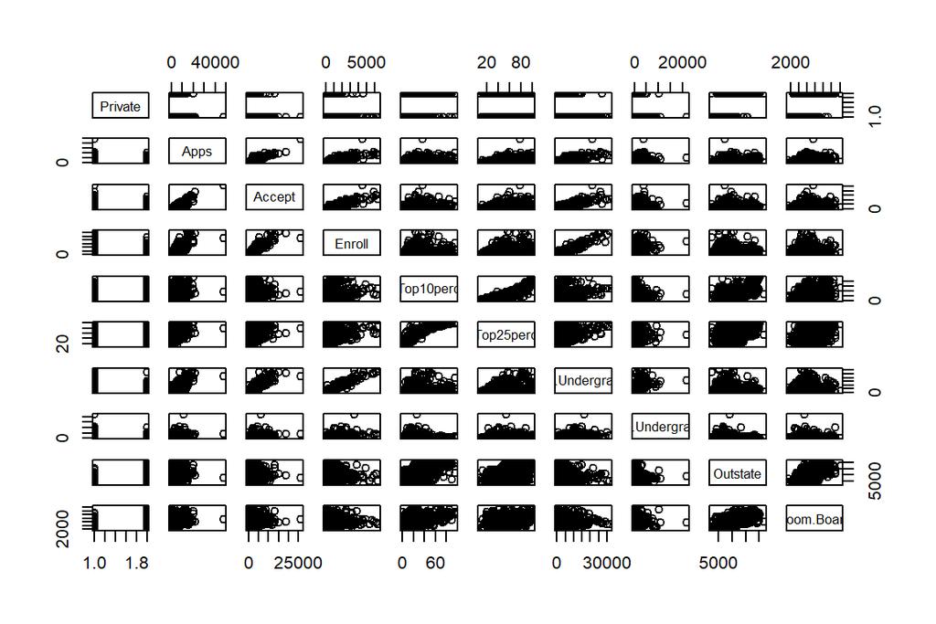

```r
prs <- pairs(college[,1:10])
```

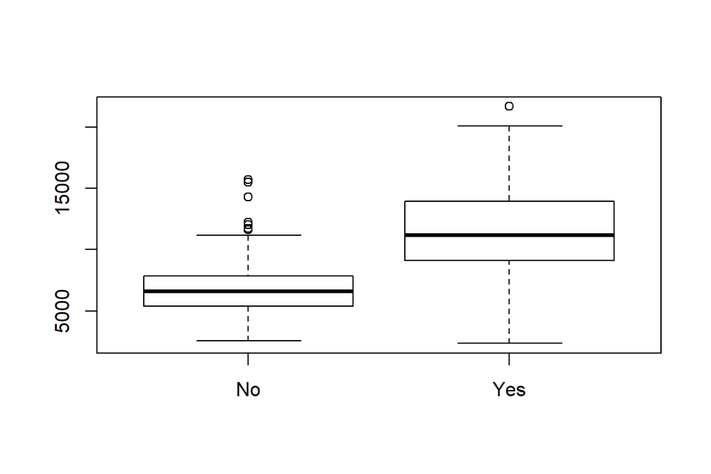

```r
boxplot(Outstate~Private,college)
```

iv. Create a new qualitative variable, called Elite, by binning the Top10perc variable. We are going to divide universities into two groups based on whether or not the proportion of students coming from the top 10% of their high school classes exceeds 50%.

Use the summary() function to see how many elite universities there are. Now use the plot() function to produce side-by-side boxplots of Outstate versus Elite.

```r
Elite =rep ("No",nrow(college ))
Elite [college$Top10perc >50]=" Yes"
Elite =as.factor (Elite)
college =data.frame(college ,Elite)

summary(college)
```

```
##  Private        Apps           Accept          Enroll       Top10perc
##  No :212   Min.   :   81   Min.   :   72   Min.   :  35   Min.   : 1.00
##  Yes:565   1st Qu.:  776   1st Qu.:  604   1st Qu.: 242   1st Qu.:15.00
##            Median : 1558   Median : 1110   Median : 434   Median :23.00
##            Mean   : 3002   Mean   : 2019   Mean   : 780   Mean   :27.56
##            3rd Qu.: 3624   3rd Qu.: 2424   3rd Qu.: 902   3rd Qu.:35.00
##            Max.   :48094   Max.   :26330   Max.   :6392   Max.   :96.00
##    Top25perc      F.Undergrad     P.Undergrad         Outstate
##  Min.   :  9.0   Min.   :  139   Min.   :    1.0   Min.   : 2340
##  1st Qu.: 41.0   1st Qu.:  992   1st Qu.:   95.0   1st Qu.: 7320
##  Median : 54.0   Median : 1707   Median :  353.0   Median : 9990
##  Mean   : 55.8   Mean   : 3700   Mean   :  855.3   Mean   :10441
##  3rd Qu.: 69.0   3rd Qu.: 4005   3rd Qu.:  967.0   3rd Qu.:12925
##  Max.   :100.0   Max.   :31643   Max.   :21836.0   Max.   :21700
##    Room.Board       Books           Personal         PhD
##  Min.   :1780   Min.   :  96.0   Min.   : 250   Min.   :  8.00
##  1st Qu.:3597   1st Qu.: 470.0   1st Qu.: 850   1st Qu.: 62.00
##  Median :4200   Median : 500.0   Median :1200   Median : 75.00
##  Mean   :4358   Mean   : 549.4   Mean   :1341   Mean   : 72.66
##  3rd Qu.:5050   3rd Qu.: 600.0   3rd Qu.:1700   3rd Qu.: 85.00
##  Max.   :8124   Max.   :2340.0   Max.   :6800   Max.   :103.00
##     Terminal       S.F.Ratio      perc.alumni        Expend
##  Min.   : 24.0   Min.   : 2.50   Min.   : 0.00   Min.   : 3186
##  1st Qu.: 71.0   1st Qu.:11.50   1st Qu.:13.00   1st Qu.: 6751
##  Median : 82.0   Median :13.60   Median :21.00   Median : 8377
##  Mean   : 79.7   Mean   :14.09   Mean   :22.74   Mean   : 9660
##  3rd Qu.: 92.0   3rd Qu.:16.50   3rd Qu.:31.00   3rd Qu.:10830
##  Max.   :100.0   Max.   :39.80   Max.   :64.00   Max.   :56233
##    Grad.Rate       Elite
##  Min.   : 10.00    Yes: 78
##  1st Qu.: 53.00   No  :699
##  Median : 65.00
##  Mean   : 65.46
##  3rd Qu.: 78.00
##  Max.   :118.00
```

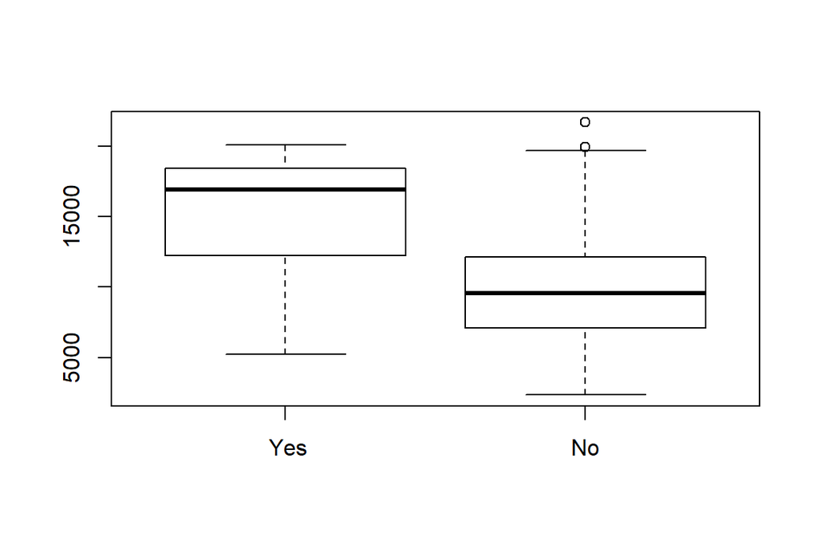

```r
boxplot(Outstate~Elite,college)
```

v. Use the hist() function to produce some histograms with differing numbers of bins for a few of the quantitative variables. You may find the command par(mfrow=c(2,2)) useful: it will divide the print window into four regions so that four plots can be made simultaneously. Modifying the arguments to this function will divide the screen in other ways.

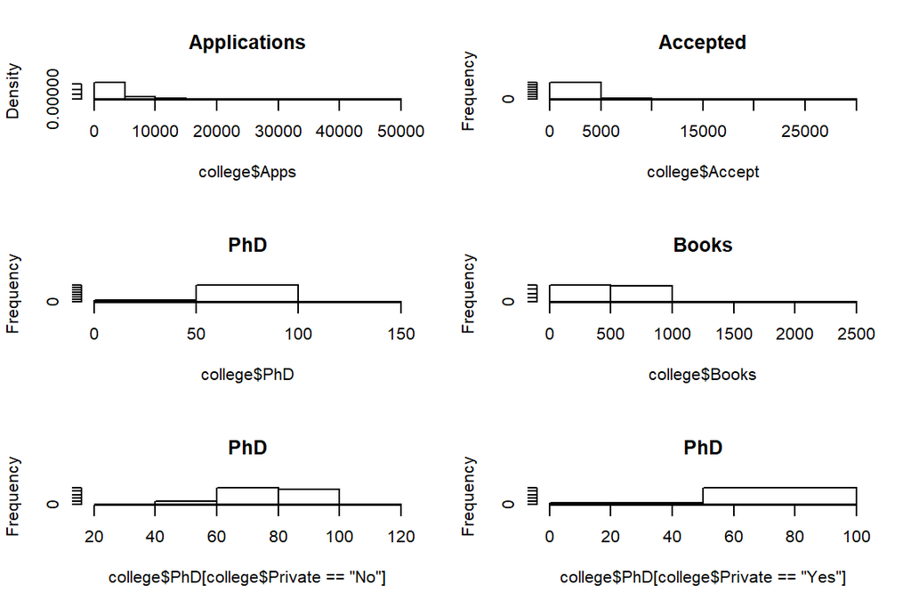

```r
par(mfrow=c(3,2))
hist(college$Apps, breaks = 10, main="Applications", freq = FALSE)
hist(college$Accept, main="Accepted", breaks = 5)
hist(college$PhD, main="PhD", breaks = 3)
hist(college$Books, main="Books", breaks = 4)
hist(college$PhD[college$Private=="No"], main="PhD", breaks = 3)
hist(college$PhD[college$Private=="Yes"], main="PhD", breaks = 3)
```

6. Continue exploring the data, and provide a brief summary of what you discover.

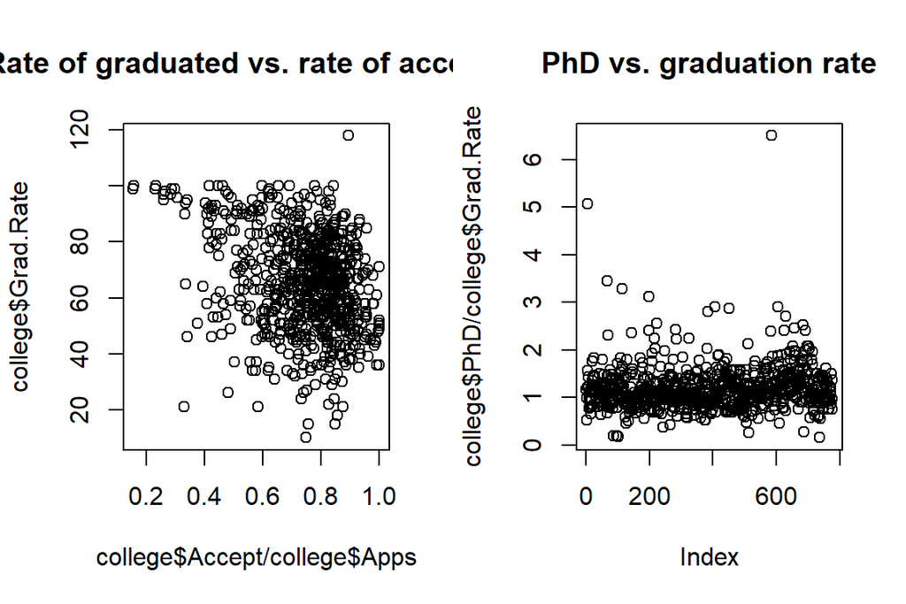

```r
par(mfrow=c(1,2))
plot(college$Accept/college$Apps,college$Grad.Rate,main="Rate of graduated vs. rate of accepted")
plot(college$PhD/college$Grad.Rate, main="PhD vs. graduation rate")
```

## Task 3

In this problem, we will test linear regression on a simple synthetic dataset. We will use the following polynomial as the underlying target function
$$y = f(x) = 2 + x − 0.5x^2$$

```r
myPoly<-function(x) {
   y = 2 + x - 0.5*x^2
}
```

```r
x = runif(30,-3,3)
x = sort(x)
errors = rnorm(30,0,0.4)
y = myPoly(x)+errors
xx = seq(-3,3,0.1)
yy = myPoly(xx)
```

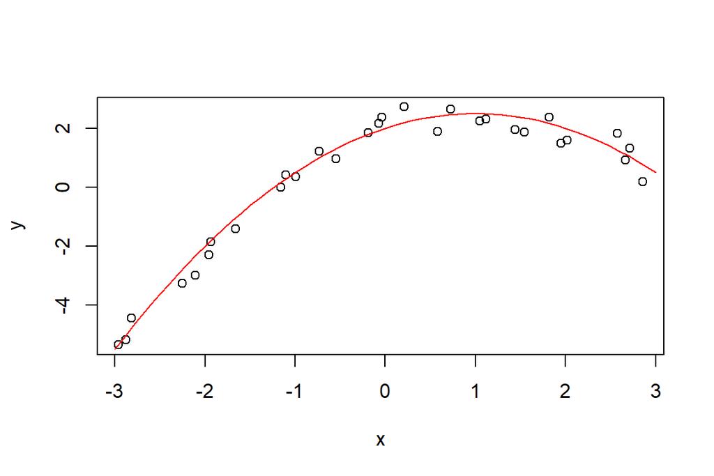

```r
plot(x,y)
lines(xx,yy,col="red")
```

(a) (4 points) First, let’s fit polynomials of order 0 to 10 to this dataset using linear regression, minimizing the sum of squares error. That is, fit functions of the form
$$\tilde{y} = \sum_{p=0}^{K}w_px^p$$

with K = 0, . . . , 10 to the data. For instance, for K = 4 the polynomial to fit is
$$\tilde{y} = w_0 + w_1x + w_2x^2 + w_3x^3 + w_4x^4.$$
For each of the 11 values of K, produce a separate plot showing the datapoints (xi , yi) and the fitted polynomial. (Plot the polynomial as a curve, in the full interval $[−3, 3]$, overlayed on the scatterplot of the points.) You should see that as the order of the polynomial K increases, the curve comes closer and closer to fitting all the datapoints.

Calculate the mean squared error (MSE) on the training data:
$$MSE = \frac{\sum_{i=1}^{n}(y_i - \tilde{y}_i)^2}{n}$$
and compare the MSE of the fitted different order models.

```r
MSE <- function(yr,yt)
{
  diff = yt - yr
  sq = diff^2
  mse = sum(sq)/length(yr)
  return(mse)
}
```

```r
pred <- function(mod,x)
{

  sz = length(mod$coefficients)

  mc = mod$coefficients
  y = mc[1]
  for (i in 2:sz)
  {
    t = mc[i]
    for (j in 2:i)
    {
      t = t*x
    }
    y = y + t
  }
  return(y)
}
```

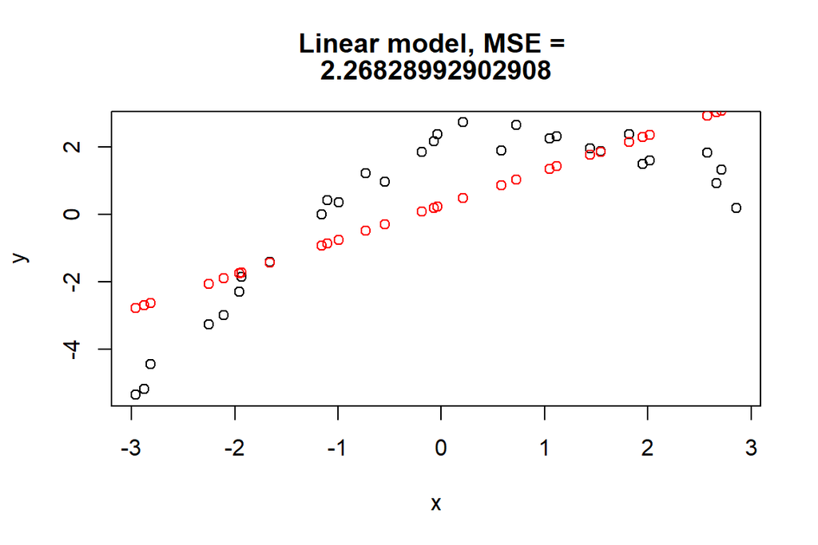

```r
m1 = lm(y ~ x) #model
mc = m1$coefficients
y1 = pred(m1,x)
mse = MSE(y,y1)
txt <- c("Linear model, MSE = ", MSE(y,y1))
plot(x,y,main=txt)
points(x,y1,col="red")
```

```r
#print("Linear model, MSE = " , MSE(y,y1))
```

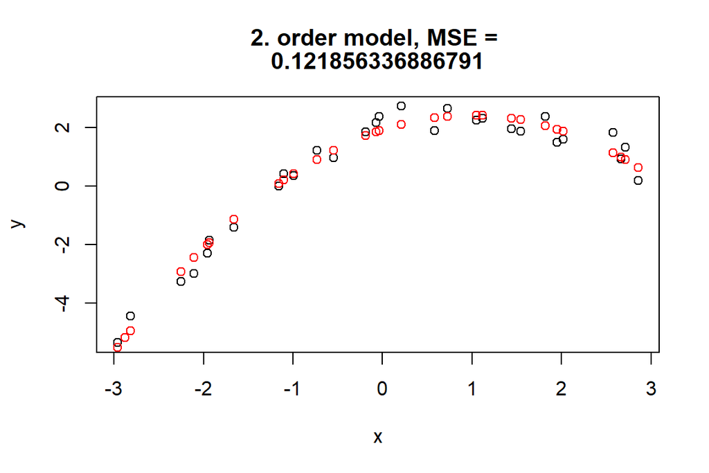

```r
m2 = lm(y ~ x + I(x^2)) #model
mc = m2$coefficients
y2 = pred(m2,x)
mse = c(mse,MSE(y,y2))
txt <- c("2. order model, MSE = ", MSE(y,y2))
plot(x,y,main=txt)
points(x,y2,col="red")
```

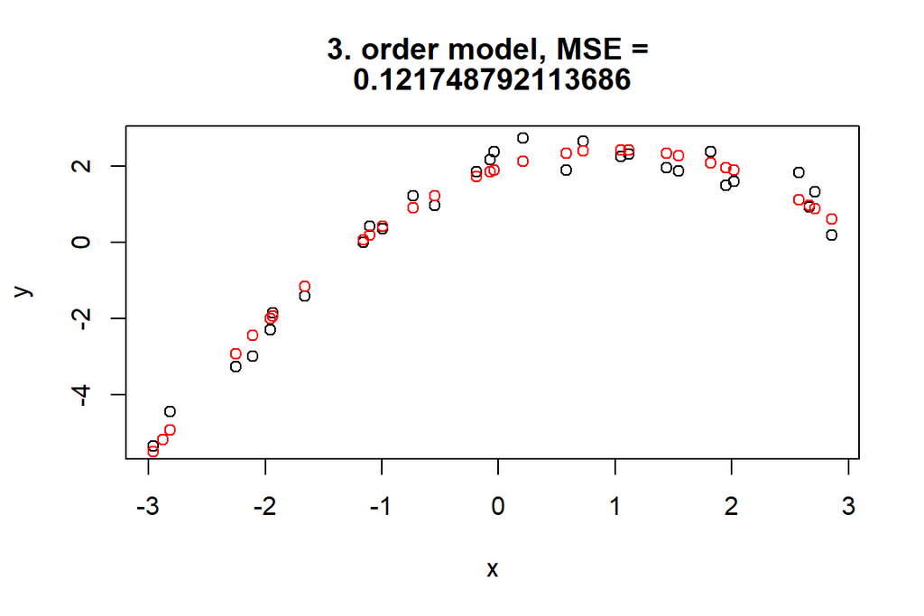

```r
m3 = lm(y ~ x + I(x^2) + I(x^3)) #model
mc = m3$coefficients
y3 = pred(m3,x)
mse = c(mse, MSE(y,y3))
txt <- c("3. order model, MSE = ", MSE(y,y3))
plot(x,y,main=txt)
points(x,y3,col="red")
```

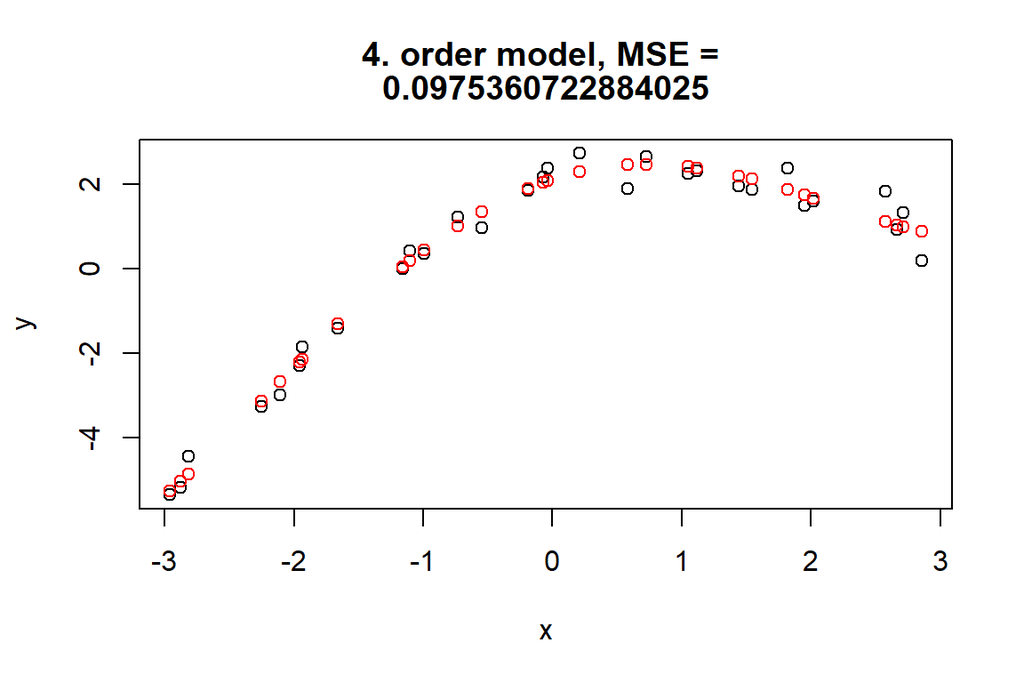

```r
m4 = lm(y ~ x + I(x^2)+ I(x^3) + I(x^4)) #model
mc = m4$coefficients
y4 = pred(m4,x)
mse = c(mse, MSE(y,y4))
txt <- c("4. order model, MSE = ", MSE(y,y4))
plot(x,y,main=txt)
points(x,y4,col="red")
```

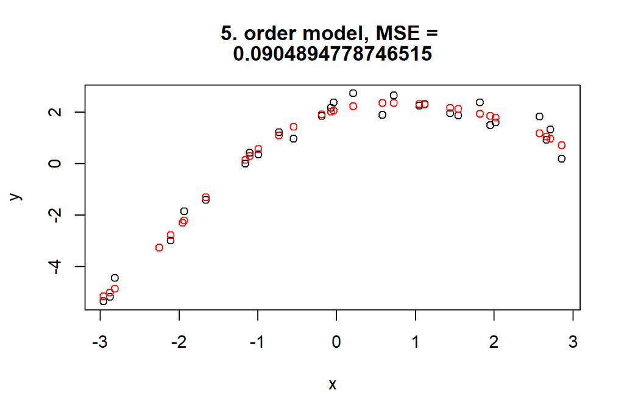

```r
m5 = lm(y ~ x + I(x^2)+ I(x^3) + I(x^4) + I(x^5)) #model
mc = m5$coefficients
y5 = pred(m5,x)
mse = c(mse, MSE(y,y5))
txt <- c("5. order model, MSE = ", MSE(y,y5))
plot(x,y,main=txt)
points(x,y5,col="red")
```

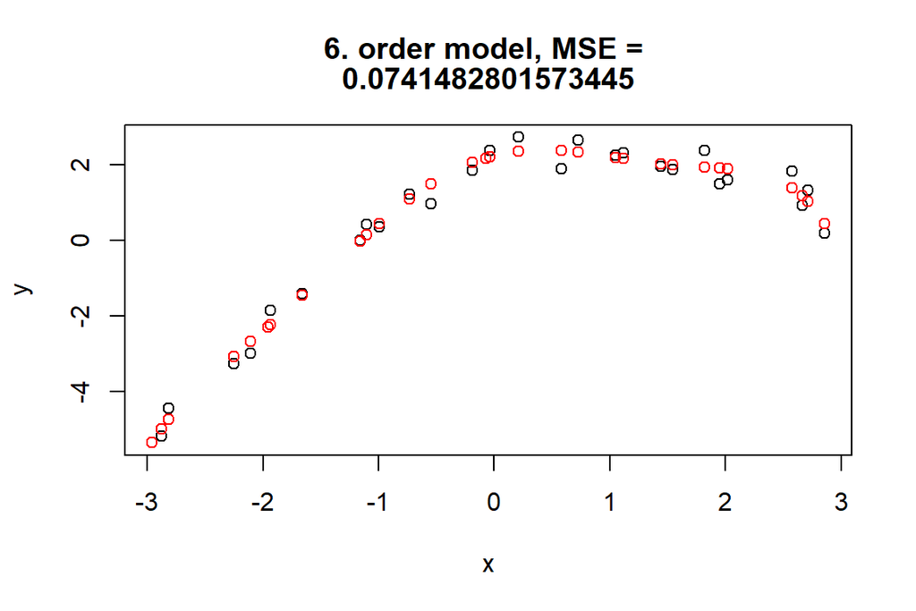

```r
m6 = lm(y ~ x + I(x^2)+ I(x^3) + I(x^4) + I(x^5) + I(x^6)) #model
mc = m5$coefficients
y6 = pred(m6,x)
mse = c(mse, MSE(y,y6))
txt <- c("6. order model, MSE = ", MSE(y,y6))
plot(x,y,main=txt)
points(x,y6,col="red")
```

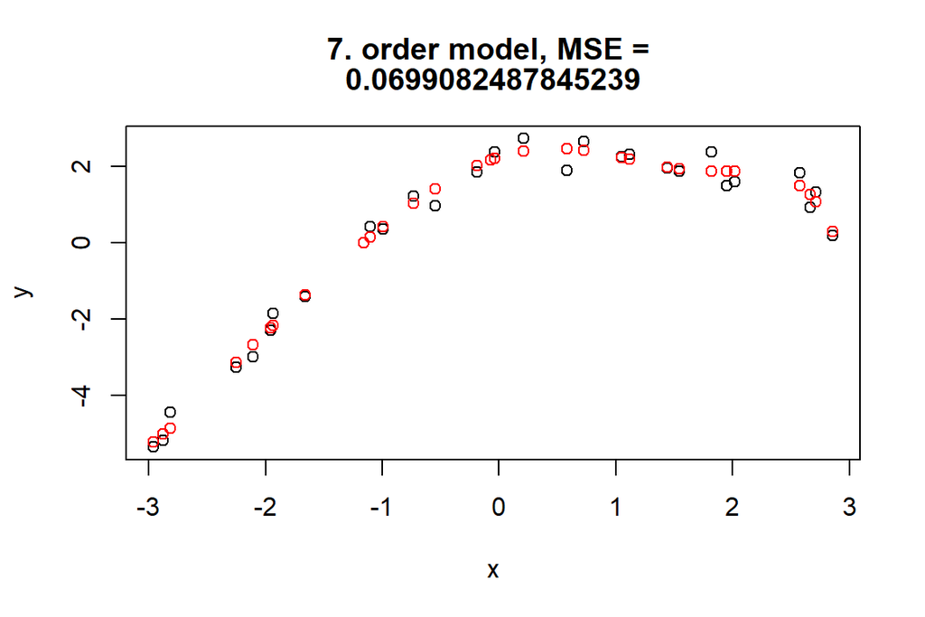

```r
m7 = lm(y ~ x + I(x^2)+ I(x^3) + I(x^4) + I(x^5) + I(x^6) + I(x^7)) #model
y7 = pred(m7,x)
mse = c(mse, MSE(y,y7))
txt <- c("7. order model, MSE = ", MSE(y,y7))
plot(x,y,main=txt)
points(x,y7,col="red")
```

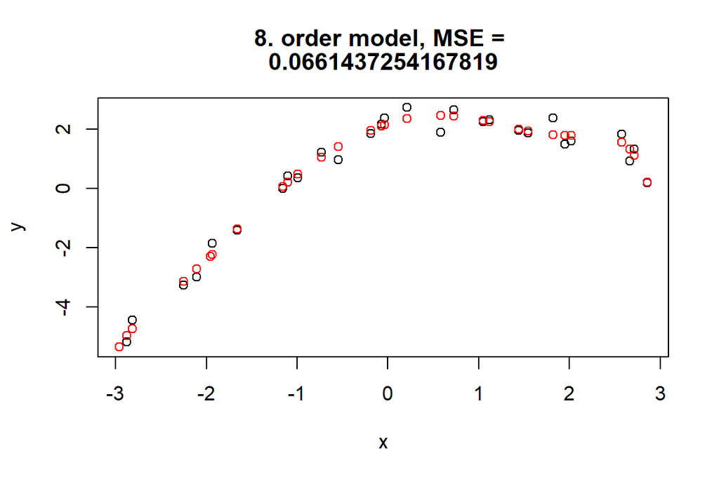

```r
m8 = lm(y ~ x + I(x^2)+ I(x^3) + I(x^4) + I(x^5) + I(x^6) + I(x^7) + I(x^8)) #model
y8 = pred(m8,x)
mse = c(mse, MSE(y,y8))
txt <- c("8. order model, MSE = ", MSE(y,y8))
plot(x,y,main=txt)
points(x,y8,col="red")
```

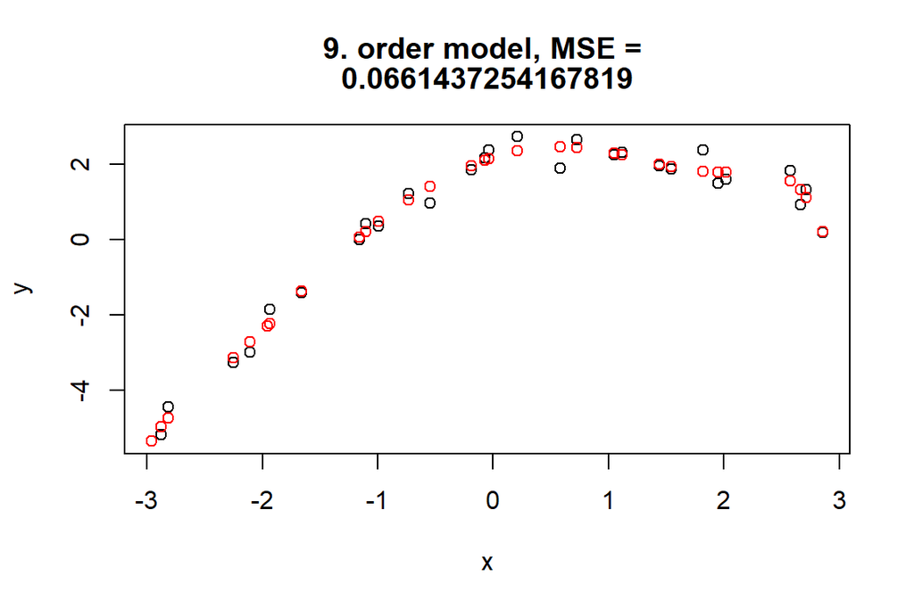

```r
m9 = lm(y ~ x + I(x^2)+ I(x^3) + I(x^4) + I(x^5) + I(x^6) + I(x^7) + I(x^8)) #model
y9 = pred(m9,x)
mse = c(mse, MSE(y,y9))
txt <- c("9. order model, MSE = ", MSE(y,y9))
plot(x,y,main=txt)
points(x,y9,col="red")
```

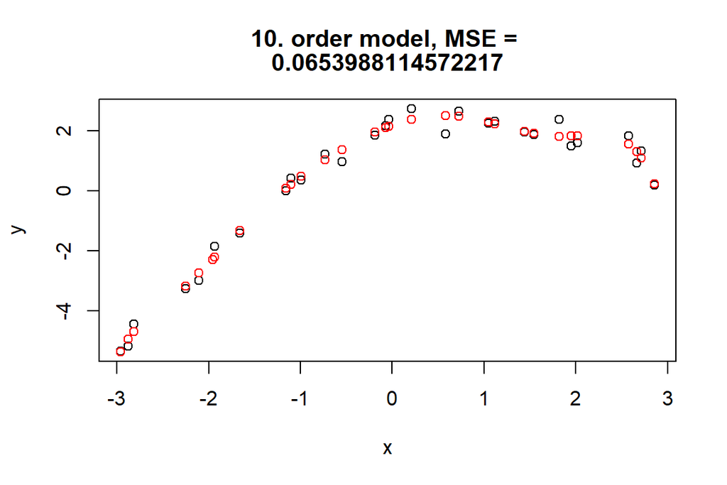

```r
m10 = lm(y ~ x + I(x^2)+ I(x^3) + I(x^4) + I(x^5) + I(x^6) + I(x^7) + I(x^8) + I(x^9)) #model
y10 = pred(m10,x)
mse = c(mse, MSE(y,y10))
txt <- c("10. order model, MSE = ", MSE(y,y10))
plot(x,y,main=txt)
points(x,y10,col="red")
```

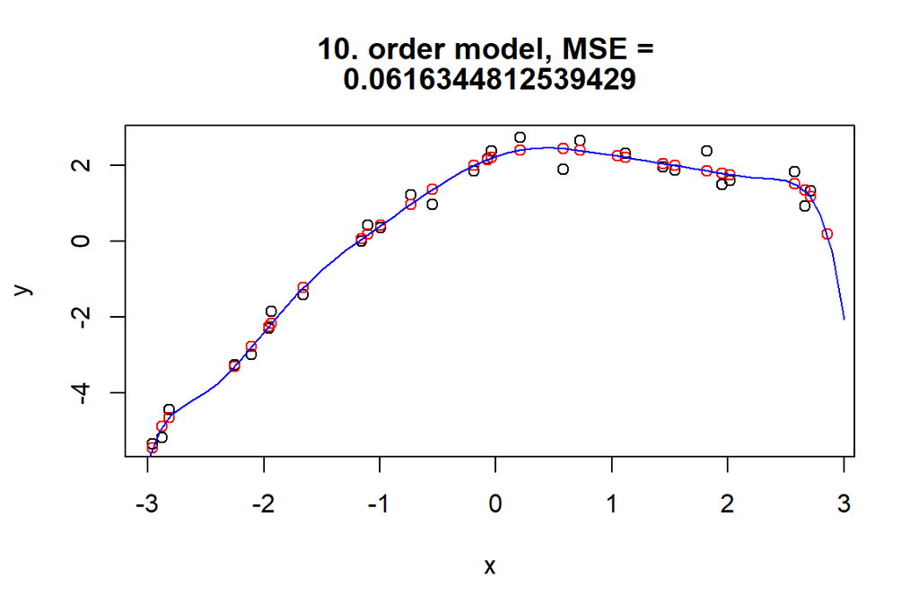

```r
m11 = lm(y ~ x + I(x^2)+ I(x^3) + I(x^4) + I(x^5) + I(x^6) + I(x^7) + I(x^8) + I(x^9) + I(x^10)) #model
y11 = pred(m11,x)
Y11 = pred(m11,xx)
mse = c(mse, MSE(y,y11))
txt <- c("10. order model, MSE = ", MSE(y,y11))
plot(x,y,main=txt)
points(x,y11,col="red")
lines(xx,Y11,col="blue")
```

2. (4 points) Next, generate 1000 more data points from the same polynomial and use them as a test set to evaluate the predictive performance of the fitted models. (Hint: The predict function that takes as arguments the fitted model and new data points will probably come in handy.) Plot both the training MSE and the test MSE as a function of the polynomial order. What do you notice?

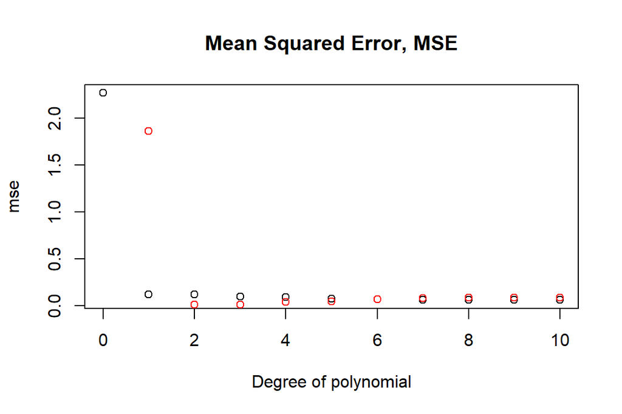

```r
x_test = runif(1000,-3,3)
x_test = sort(x_test)
y_test = myPoly(x_test)
yt1 = pred(m1,x_test)
mse_test = MSE(y_test,yt1)
yt2 = pred(m2,x_test)
mse_test = c(mse_test,MSE(y_test,yt2))
yt3 = pred(m3,x_test)
mse_test = c(mse_test,MSE(y_test,yt3))
yt4 = pred(m4,x_test)
mse_test = c(mse_test,MSE(y_test,yt4))
yt5 = pred(m5,x_test)
mse_test = c(mse_test,MSE(y_test,yt5))
yt6 = pred(m6,x_test)
mse_test = c(mse_test,MSE(y_test,yt6))
yt7 = pred(m7,x_test)
mse_test = c(mse_test,MSE(y_test,yt7))
yt8 = pred(m8,x_test)
mse_test = c(mse_test,MSE(y_test,yt8))
yt9 = pred(m9,x_test)
mse_test = c(mse_test,MSE(y_test,yt9))
yt10 = pred(m10,x_test)
mse_test = c(mse_test,MSE(y_test,yt10))
yt11 = pred(m11,x_test)
mse_test = c(mse_test,MSE(y_test,yt11))
plot(0:10, mse, xlab = "Degree of polynomial", main = "Mean Squared Error, MSE")
points(mse_test,col="red")
```

Conclusion: With low degree polynomial models the standard error is smaller and it grows as the model degree gets higher. This is because the model created begins to model the random error created in the model x data making the prediction worse –> OVERFITTING

3. (4 points) Finally, let’s use a technique called 10-fold cross-validation to automatically select a model based on the 30 training examples we have. Divide the dataset into 10 equal-sized subsets (i.e. 3 datapoints in each subset), and, for each value of K = 0, . . . , 11 and each data subset j = 1, . . . 10, use all the data except the data in subset j to fit the polynomial of order K, and compute the resulting sum of squared errors on subset j. For each value of K, sum together the squared errors coming from the different folds j. Plot these results with K on the horizontal axis, and the sum of squared errors on the vertical axis. How does this function behave? Does the cross-validated error improve with increasing K? Which K gives the minimum error?

Generate two more help functions, buildModel will generate a string representing nth degree polynomial, myModel will create the actual linear model using the nth degree polynomial

```r
buildModel <- function(dgr)
{
  modStr = ""
  txt = "x"
  for (i in 2:dgr)
  {
    txt = paste(txt, " + I(x^", i, ")", sep="")
  }
  return(txt)
  #x + I(x^2)+ I(x^3) + I(x^4) + I(x^5) + I(x^6) + I(x^7) + I(x^8) + I(x^9) + I(x^10)
}
```

```r
myModel <- function(x,y,degree)
{
  modTxt = buildModel(degree)
  modTxt = paste("lm(y~", modTxt, ")", sep="")
  mod = eval(parse(text = modTxt))
  return(mod)
}
```

```r
#generate the data
x = runif(30,-3,3)
errors = rnorm(30,0,0.4)
y = myPoly(x)+errors

folds <- cut(seq(1,length(x)),breaks=10,labels=FALSE)

#cross validation mse, create vector of zeros
(mse_cv = numeric(10)) #one for each value of K
```

```
##  [1] 0 0 0 0 0 0 0 0 0 0
```

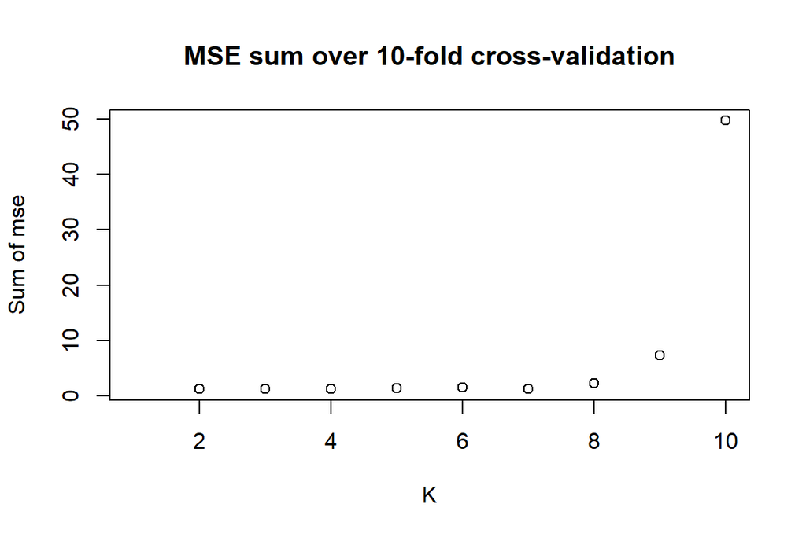

```r
for (K in 1:10)
{
  #for each subset of data
  for (set in 1:10)
  {
    #data used to model and cross validate
    x_s_mod = x[folds != set]
    y_s_mod = y[folds != set]
    x_s_test = x[folds == set]
    y_s_test = y[folds == set]
    #build model
    mod = myModel(x_s_mod, y_s_mod, K)

    #predict with model
    y_s_cv = pred(mod,x_s_test)
    #calculate the MSE for the validation data and add to sum for this K
    mse_cv[K] = mse_cv[K] + MSE(y_s_test,y_s_cv)
  }
}
plot(1:10,mse_cv,xlab = "K", ylab = "Sum of mse", main = "MSE sum over 10-fold cross-validation")
```

```r
folds <- cut(seq(1,length(x)),breaks=10,labels=FALSE)
x[folds != 3]
```

```
##  [1] -0.407517054 -1.786368473  0.678681765  1.957706460  1.622882696
##  [6] -2.485398988 -1.670259114  0.009198579  1.211500822 -0.549418242
## [11]  0.723619260 -2.684885178  2.947547805 -1.914730908 -1.062183869
## [16] -0.543201136  0.941357021 -2.380782508  1.909916968 -2.391154140
## [21] -2.824363335 -0.628743771  1.453357397 -1.850006646  1.626344895
## [26]  0.909316664 -1.381944034
```